# Tugas 4 Individu PDP (1) due to 25 nov 2022 12.00

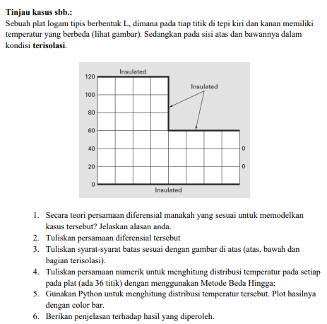

- Nama : Muhammad Rizky Anugrah
- NIM : 1306620089
- Kelas: Fisika B
- Dosen: Dr.rer.nat. Bambang Heru Iswanto

## Nomor 1

1. Secara teori persamaan diferensial manakah yang sesuai untuk memodelkan kasus tersebut? Jelaskan alasan anda.

Teori persamaan differennsial yang sesuai unntuk memodelkan kasus tersebut ialah persamaan eliptik. Persamaan eliptik biasanya digunakan untuk mengkarakterisasi sistem setimbang. Seperti di persamaan Laplace, hal ini ditunjukkan dengan tidak adanya turunan waktu. Dengan demikian, persamaan ini biasanya digunakan untuk menentukan distribusi keadaan tunak dari yang tidak diketahui dalam dua dimensi spasial.

## Nomor 2

1. Tuliskan persamaan diferensial tersebut

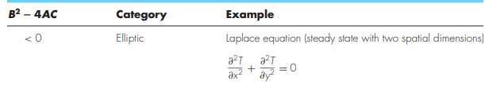

## Nomor 3

1. Tuliskan syarat-syarat batas sesuai dengan gambar di atas (atas, bawah dan bagian terisolasi).
- Titik Terisolasi Atas dan Bawah

$$\frac{\partial^2T}{\partial y^2} = 0$$

- Titik Terisolasi Kanan

$$\frac{\partial^2T}{\partial x^2} = 0$$

- Titik Bagian Kiri

$$\frac{\partial^2T}{\partial x^2} + \frac{\partial^2T}{\partial y^2} = 0$$$$T = 120^{\circ}C - 0^{\circ}C = 120^{\circ}C$$

- Titik Bagian Kanan

$$\frac{\partial^2T}{\partial x^2} + \frac{\partial^2T}{\partial y^2} = 0$$$$T = 0^{\circ}C$$

## Nomor 4

1. Tuliskan persamaan numerik untuk menghitung distribusi temperatur pada setiap pada plat (ada 36 titik) dengan menggunakan Metode Beda Hingga;
- Persamaan Laplace $$\frac{\partial^2T}{\partial x^2} + \frac{\partial^2T}{\partial y^2} = 0$$
- Central Differences

$$\frac{\partial^2 T}{\partial x^2}=\frac{T_{i+1, j}-2 T_{i, j}+T_{i-1, j}}{\Delta x^2}$$$$\frac{\partial^2 T}{\partial y^2}=\frac{T_{i, j+1}-2 T_{i, j}+T_{i, j-1}}{\Delta y^2}$$

- Subtitusikan nilai differensial orde 2 ke dalam rumus laplace

$$\frac{T_{i+1, j}-2 T_{i, j}+T_{i-1, j}}{\Delta x^2} + \frac{T_{i, j+1}-2 T_{i, j}+T_{i, j-1}}{\Delta y^2} = 0$$

- Pada kasus ini nilai $\Delta x = \Delta y$ maka

$$T_{i+1, j}+T_{i-1, j}+T_{i, j+1}+T_{i, j-1}-4 T_{i, j}=0$$$$T_{i, j}=\frac{T_{i+1, j}+T_{i-1, j}+T_{i, j+1}+T_{i, j-1}}{4}$$

- Misalkan ialah titik i = 0, j = 0, maka:

$$T_{0,0}=\frac{T_{1,0}+T_{-1,0}+T_{0,1}+T_{0,-1}}{4}$$$$T_{0,0}=\frac{T_{1,0}+T_{0,1}}{2}$$

## Nomor 5

1. Gunakan Python untuk menghitung distribusi temperatur tersebut. Plot hasilnya dengan color bar

```python
import matplotlib.pyplot as plt
import numpy as np
import seaborn as sns
```

[output not shown]

## Matriks

```python
Width = 7
Length = 9
matriks = []
for i in range(Width):
    list_kosong = []
    for j in range(Length):
        koordinat = [i,j]
        list_kosong.append(koordinat)
    matriks.append(list_kosong)
matriks
```

```
[[[0, 0], [0, 1], [0, 2], [0, 3], [0, 4], [0, 5], [0, 6], [0, 7], [0, 8]],
 [[1, 0], [1, 1], [1, 2], [1, 3], [1, 4], [1, 5], [1, 6], [1, 7], [1, 8]],
 [[2, 0], [2, 1], [2, 2], [2, 3], [2, 4], [2, 5], [2, 6], [2, 7], [2, 8]],
 [[3, 0], [3, 1], [3, 2], [3, 3], [3, 4], [3, 5], [3, 6], [3, 7], [3, 8]],
 [[4, 0], [4, 1], [4, 2], [4, 3], [4, 4], [4, 5], [4, 6], [4, 7], [4, 8]],
 [[5, 0], [5, 1], [5, 2], [5, 3], [5, 4], [5, 5], [5, 6], [5, 7], [5, 8]],
 [[6, 0], [6, 1], [6, 2], [6, 3], [6, 4], [6, 5], [6, 6], [6, 7], [6, 8]]]
```

## Matriks Sesuai Soal

```python
for i in range(3):
    del matriks[i][5:9]
matriks
```

```
[[[0, 0], [0, 1], [0, 2], [0, 3], [0, 4]],
 [[1, 0], [1, 1], [1, 2], [1, 3], [1, 4]],
 [[2, 0], [2, 1], [2, 2], [2, 3], [2, 4]],
 [[3, 0], [3, 1], [3, 2], [3, 3], [3, 4], [3, 5], [3, 6], [3, 7], [3, 8]],
 [[4, 0], [4, 1], [4, 2], [4, 3], [4, 4], [4, 5], [4, 6], [4, 7], [4, 8]],
 [[5, 0], [5, 1], [5, 2], [5, 3], [5, 4], [5, 5], [5, 6], [5, 7], [5, 8]],
 [[6, 0], [6, 1], [6, 2], [6, 3], [6, 4], [6, 5], [6, 6], [6, 7], [6, 8]]]
```

```python
matriks = np.zeros((Width,Length))
for i in range(Width):
    matriks[i][0] += 120 - 20*i
matriks
```

```
array([[120.,   0.,   0.,   0.,   0.,   0.,   0.,   0.,   0.],
       [100.,   0.,   0.,   0.,   0.,   0.,   0.,   0.,   0.],
       [ 80.,   0.,   0.,   0.,   0.,   0.,   0.,   0.,   0.],
       [ 60.,   0.,   0.,   0.,   0.,   0.,   0.,   0.,   0.],
       [ 40.,   0.,   0.,   0.,   0.,   0.,   0.,   0.,   0.],
       [ 20.,   0.,   0.,   0.,   0.,   0.,   0.,   0.,   0.],
       [  0.,   0.,   0.,   0.,   0.,   0.,   0.,   0.,   0.]])
```

## Fungsi

```python
def central_differences(tabel,tabel_lama,i,j,Length,Width,Employ_overrelaxation=1.5):
    a = i + 1
    b = i - 1
    c = j + 1
    d = j - 1
    if a >= Width:
        a -= 2
    if b < 0:
        b += 2
    if c >= Length:
        c -= 2
    if d < 0 :
        d += 2
    list_kosong = np.zeros(1)
    list_kosong = round(1/4*(tabel[a][j] + tabel[b][j] + tabel[i][c] + tabel[i][d]),3)
    hasil = round(Employ_overrelaxation*list_kosong + (1-Employ_overrelaxation)*tabel_lama[i][j],3)
    return round(hasil,4)
```

```python
def Error(tabel,tabel_lama,y,x):
    list_kosong = np.zeros(1)
    list_kosong = np.abs((tabel[y][x] - tabel_lama[y][x]) / tabel_lama[y][x])*100
    return list_kosong
```

## Menghitung T

```python
tabel = matriks.copy()
tabel_lama = matriks.copy()

for x in range(1,4):
    for y in range(Width):
        tabel[y][x] = round(central_differences(tabel,tabel_lama,y,x,Length,Width),3)
for x in range(4,5):
    for y in range(0,4):
        tabel[y][x] = round(central_differences(tabel,tabel_lama,y,x,5,Width),3)
for x in range(4,8):
    for y in range(4,Width):
        tabel[y][x] = round(central_differences(tabel,tabel_lama,y,x,Length,Width),3)

for i in range(20):
    tabel_lama = tabel.copy()
    error = np.zeros((Width,Length))
    for x in range(1,4):
        for y in range(Width):
            tabel[y][x] = round(central_differences(tabel,tabel_lama,y,x,Length,Width),3)
            error[y][x] = round(Error(tabel,tabel_lama,y,x),3)
    for x in range(4,5):
        for y in range(0,4):
            tabel[y][x] = round(central_differences(tabel,tabel_lama,y,x,5,Width),3)
            error[y][x] = round(Error(tabel,tabel_lama,y,x),3)
    for x in range(4,8):
        for y in range(4,Width):
            tabel[y][x] = round(central_differences(tabel,tabel_lama,y,x,Length,Width),3)
            error[y][x] = round(Error(tabel,tabel_lama,y,x),3)

    sum_err = np.sum(error)
    rata = sum_err/37
    if rata < 1:
        Nilai_iter = i + 1
        break
```

```python
print('Soal \n', matriks)
print('Nilai T setiap titik \n', tabel)
print('Nilai Error \n', error)
```

```
Soal
 [[120.   0.   0.   0.   0.   0.   0.   0.   0.]
 [100.   0.   0.   0.   0.   0.   0.   0.   0.]
 [ 80.   0.   0.   0.   0.   0.   0.   0.   0.]
 [ 60.   0.   0.   0.   0.   0.   0.   0.   0.]
 [ 40.   0.   0.   0.   0.   0.   0.   0.   0.]
 [ 20.   0.   0.   0.   0.   0.   0.   0.   0.]
 [  0.   0.   0.   0.   0.   0.   0.   0.   0.]]
Nilai T setiap titik
 [[120.     89.159  73.5    65.773  63.679   0.      0.      0.      0.   ]
 [100.     82.178  70.234  63.636  61.713   0.      0.      0.      0.   ]
 [ 80.     69.821  62.058  57.157  55.437   0.      0.      0.      0.   ]
 [ 60.     55.479  51.342  47.72   45.336   0.      0.      0.      0.   ]
 [ 40.     41.036  40.333  37.184  30.162  13.002   6.086   2.506   0.   ]
 [ 20.     28.543  31.94   30.629  25.072  15.794   8.856   3.938   0.   ]
 [  0.     21.365  28.429  28.387  23.73   16.254   9.603   4.378   0.   ]]
Nilai Error
 [[0.    0.831 1.424 1.702 1.662 0.    0.    0.    0.   ]
 [0.    0.716 1.208 1.422 1.348 0.    0.    0.    0.   ]
 [0.    0.64  1.073 1.238 1.155 0.    0.    0.    0.   ]
 [0.    0.66  0.985 1.106 1.021 0.    0.    0.    0.   ]
 [0.    0.648 0.923 1.024 1.025 0.947 0.929 0.886 0.   ]
 [0.    0.691 0.894 1.006 0.93  0.901 0.843 0.716 0.   ]
 [0.    0.679 0.873 0.863 0.824 0.769 0.713 0.551 0.   ]]
```

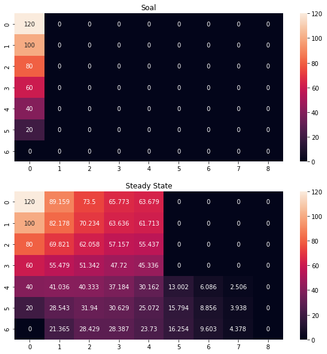

```python
fig = plt.figure(figsize=(10,10))
fig.patch.set_facecolor('xkcd:white')
plt.subplot(211)
sns.heatmap(data = matriks, annot=True, fmt='g')
plt.title('Soal')
plt.subplot(212)
sns.heatmap(data = tabel, annot=True, fmt='g')
plt.title('Steady State')
plt.show()
```

## Nomor 6

1. Berikan penjelasan terhadap hasil yang diperoleh.

Berdasarkan hasil yang telah diperoleh nilai pada suhu tertinggi yaitu $120^{\circ}C$ memiliki warna yang sangat terang dan pada suhu terendah yaitu $0^{\circ}C$ yaitu berwarna hitam. Dengan menggunakan persamaan laplace untuk menghitung setiap tyang didapatkan dari masing-masing titik dengan rumus centrak differences maka dapat dilihat bahwa suhu tertinggi yang didapatkan yaitu $89.159^{\circ}C$ dan suhu terendah yang didapatkan ialah $2.506^{\circ}C$